# L4 Factor Models

FIN 3380: Introduction to Financial Data Analysis

Week 9-10

## Load packages

```r
setwd("C:/Users/siche/Documents/teaching/Introduction to Financial Data Analysis/L4/")
library(zoo)
library(tidyr)
library(dplyr)
library(RPostgres)
```

## Step 1. Get 5 stocks daily returns from WRDS

- use the same permno selected in L2, only select the first 5 stocks
- Date is from ‘2008-01-01’ to ‘2010-12-31’
- Save data as “crsp.roll.RData”

```r
source("C:/Users/siche/Documents/teaching/Introduction to Financial Data Analysis/wrds.R")
load("C:/Users/siche/Documents/teaching/Introduction to Financial Data Analysis/L2/permnos.RData")
permnos = paste0(permnos[1:5],collapse = ',')

q=paste0("select permno,date,ret from CRSP.DSF where permno in (",
         permnos,
         ") and date>='2008-01-01'")
res = dbSendQuery(wrds, q)
crsp.roll = dbFetch(res, n=-1)
dbClearResult(res)
save(crsp.roll,file='crsp.roll.RData')
```

```r
load("crsp.roll.RData")
head(crsp.roll)
```

```
##   permno       date          ret
## 1  11600 2008-01-02 -0.028876038
## 2  11600 2008-01-03  0.009377856
## 3  11600 2008-01-04 -0.019261325
## 4  11600 2008-01-07  0.024029596
## 5  11600 2008-01-08  0.005415200
## 6  11600 2008-01-09  0.028052064
```

```r
crsp.roll = crsp.roll %>% filter(date<'2011-01-01')
```

- Check the number of observations for each stock

```r
crsp.roll %>% group_by(permno) %>% summarise(n=n())
```

```
## # A tibble: 5 x 2
##   permno     n
##    <dbl> <int>
## 1  11600   757
## 2  13610   757
## 3  39731   757
## 4  79089   757
## 5  83148   757
```

## Step 2. Get fama french daily factor data and merge it with stock returns

- read ff daily factor data

```r
ff = read.csv("ff_daily.csv",skip=4)
head(ff)
```

```
##          X Mkt.RF   SMB   HML    RF
## 1 19260701   0.10 -0.24 -0.28 0.009
## 2 19260702   0.45 -0.32 -0.08 0.009
## 3 19260706   0.17  0.27 -0.35 0.009
## 4 19260707   0.09 -0.59  0.03 0.009
## 5 19260708   0.21 -0.36  0.15 0.009
## 6 19260709  -0.71  0.44  0.56 0.009
```

```r
# rename each column
colnames(ff) = c("date","mkt.rf","smb","hml","rf")
head(ff)
```

```
##       date mkt.rf   smb   hml    rf
## 1 19260701   0.10 -0.24 -0.28 0.009
## 2 19260702   0.45 -0.32 -0.08 0.009
## 3 19260706   0.17  0.27 -0.35 0.009
## 4 19260707   0.09 -0.59  0.03 0.009
## 5 19260708   0.21 -0.36  0.15 0.009
## 6 19260709  -0.71  0.44  0.56 0.009
```

```r
tail(ff)
```

```
##                                   date mkt.rf   smb   hml    rf
## 24556                         20190827  -0.46 -0.87 -0.68 0.007
## 24557                         20190828   0.68  0.47  0.62 0.007
## 24558                         20190829   1.35  0.31  0.34 0.007
## 24559                         20190830   0.03 -0.38  0.26 0.007
## 24560                                      NA    NA    NA    NA
## 24561 Copyright 2019 Kenneth R. French     NA    NA    NA    NA
```

- reformat the date
- change each column to absolute value from percentage value
- remove the NAs at the end of the dataset using na.omit()

```r
ff = ff %>% mutate(date = as.Date(date,"%Y%m%d")) %>%
  mutate(mkt.rf = mkt.rf/100, rf = rf/100,
         smb = smb/100, hml = hml/100) %>%
  na.omit()
head(ff)
```

```
##         date  mkt.rf     smb     hml    rf
## 1 1926-07-01  0.0010 -0.0024 -0.0028 9e-05
## 2 1926-07-02  0.0045 -0.0032 -0.0008 9e-05
## 3 1926-07-06  0.0017  0.0027 -0.0035 9e-05
## 4 1926-07-07  0.0009 -0.0059  0.0003 9e-05
## 5 1926-07-08  0.0021 -0.0036  0.0015 9e-05
## 6 1926-07-09 -0.0071  0.0044  0.0056 9e-05
```

```r
tail(ff)
```

```
##             date  mkt.rf     smb     hml    rf
## 24554 2019-08-23 -0.0266 -0.0055 -0.0021 7e-05
## 24555 2019-08-26  0.0108 -0.0002 -0.0021 7e-05
## 24556 2019-08-27 -0.0046 -0.0087 -0.0068 7e-05
## 24557 2019-08-28  0.0068  0.0047  0.0062 7e-05
## 24558 2019-08-29  0.0135  0.0031  0.0034 7e-05
## 24559 2019-08-30  0.0003 -0.0038  0.0026 7e-05
```

- merge ff and stock returns on date
- calculate the excess returns of each stock

```r
crsp.roll = crsp.roll %>% left_join(ff,by="date") %>%
  mutate(ret.rf = ret-rf)
head(crsp.roll)
```

```
##   permno       date          ret  mkt.rf     smb     hml    rf
## 1  11600 2008-01-02 -0.028876038 -0.0146 -0.0010 -0.0010 1e-04
## 2  11600 2008-01-03  0.009377856 -0.0014 -0.0102 -0.0037 1e-04
## 3  11600 2008-01-04 -0.019261325 -0.0256 -0.0050  0.0013 1e-04
## 4  11600 2008-01-07  0.024029596  0.0016  0.0011  0.0013 1e-04
## 5  11600 2008-01-08  0.005415200 -0.0181 -0.0043 -0.0086 1e-04
## 6  11600 2008-01-09  0.028052064  0.0110 -0.0036 -0.0063 1e-04
##         ret.rf
## 1 -0.028976038
## 2  0.009277856
## 3 -0.019361325
## 4  0.023929596
## 5  0.005315200
## 6  0.027952064
```

## Step 3. Rolling window regression example for one stock

- Subset the first stock for example

```r
stock.1 = crsp.roll %>% filter(permno == first(permno))
```

- Use rollify function from library(tibbletime) to write a rolling linear regression function of excess returns on all 3 factors
- rollify(.f = function(x,y,z){}, window, unlist) returns a rolling version of the input function, with a rolling window specified by the user.

```r
library(tibbletime)
win = 252
Roll.Lm = rollify(.f = function(ret.rf, mkt.rf, smb, hml) {
  lm(ret.rf ~ mkt.rf + smb + hml)
  },
  window = win, unlist = FALSE)
```

- tibble type data frame allows list as a column variable, we prepare the stock.1 to take the linear regression result as one column

```r
stock.1 = as_tibble(stock.1)
head(stock.1)
```

```
## # A tibble: 6 x 8
##   permno date            ret  mkt.rf     smb     hml     rf   ret.rf
##    <dbl> <date>        <dbl>   <dbl>   <dbl>   <dbl>  <dbl>    <dbl>
## 1  11600 2008-01-02 -0.0289  -0.0146 -0.001  -0.001  0.0001 -0.0290
## 2  11600 2008-01-03  0.00938 -0.0014 -0.0102 -0.0037 0.0001  0.00928
## 3  11600 2008-01-04 -0.0193  -0.0256 -0.005   0.0013 0.0001 -0.0194
## 4  11600 2008-01-07  0.0240   0.0016  0.0011  0.0013 0.0001  0.0239
## 5  11600 2008-01-08  0.00542 -0.0181 -0.0043 -0.0086 0.0001  0.00532
## 6  11600 2008-01-09  0.0281   0.011  -0.0036 -0.0063 0.0001  0.0280
```

- use your user defined Roll.Lm function to do rolling regression on your stock 1, put the linear regression result into a column called model
- Use slice() function to remove the 1:251 which do not have regression result.
- slice(df,n) will keep the row indexed by n. slice(df,-n) will delete rows indexed by n

```r
tmprst = stock.1 %>%
  mutate(model = Roll.Lm(ret.rf, mkt.rf, smb, hml)) %>%
  select(date, model) %>%
  slice(-1:-251)
head(tmprst)
```

```
## # A tibble: 6 x 2
##   date       model
##   <date>     <list>
## 1 2008-12-30 <lm>
## 2 2008-12-31 <lm>
## 3 2009-01-02 <lm>
## 4 2009-01-05 <lm>
## 5 2009-01-06 <lm>
## 6 2009-01-07 <lm>
```

```r
tmprst$model[1:3]
```

```
## [[1]]
##
## Call:
## lm(formula = ret.rf ~ mkt.rf + smb + hml)
##
## Coefficients:
## (Intercept)       mkt.rf          smb          hml
##  -0.0005406    0.7133061    0.1728848    0.0414196
##
##
## [[2]]
##
## Call:
## lm(formula = ret.rf ~ mkt.rf + smb + hml)
##
## Coefficients:
## (Intercept)       mkt.rf          smb          hml
##  -0.0004317    0.7130775    0.1790641    0.0433924
##
##
## [[3]]
##
## Call:
## lm(formula = ret.rf ~ mkt.rf + smb + hml)
##
## Coefficients:
## (Intercept)       mkt.rf          smb          hml
##  -0.0004318    0.7158649    0.1792817    0.0413688
```

- Unwrap the column called “model” into a dataframe, using the tidy() and map() and unnest()
- tidy() function from library(broom) summarizes information about the components of a linear regression model. In general, tidy() can turn an structured object into a dataframe of tibble format.
- The map() function from library(purrr) transform their input(a list or a vector) by applying a function to each element and returning a vector the same length as the input.
- unnest() function from tidyr can flattens a list back out into regular columns.
- unnest() require at least tidyr 1.0.0
- More specificly, we use map() to apply the tidy() function on each element(the list result from regression) in the “model” column, so that each element in the “model” is a dataframe. We then use unnest() function to change the column “model” which contain dataframe into multiple new columns in which the data are simply vectors.

```r
library(broom)
library(purrr)
tmprst = tmprst %>% mutate(model = map(model,tidy))
head(tmprst)
```

```
## # A tibble: 6 x 2
##   date       model
##   <date>     <list>
## 1 2008-12-30 <tibble [4 x 5]>
## 2 2008-12-31 <tibble [4 x 5]>
## 3 2009-01-02 <tibble [4 x 5]>
## 4 2009-01-05 <tibble [4 x 5]>
## 5 2009-01-06 <tibble [4 x 5]>
## 6 2009-01-07 <tibble [4 x 5]>
```

```r
tmprst$model[[1]]
```

```
## # A tibble: 4 x 5
##   term         estimate std.error statistic  p.value
##   <chr>           <dbl>     <dbl>     <dbl>    <dbl>
## 1 (Intercept) -0.000541   0.00111    -0.485 6.28e- 1
## 2 mkt.rf       0.713      0.0492     14.5   7.03e-35
## 3 smb          0.173      0.122       1.42  1.56e- 1
## 4 hml          0.0414     0.0933      0.444 6.57e- 1
```

```r
tmprst = tmprst %>% unnest(model)
head(tmprst,10)
```

```
## # A tibble: 10 x 6
##    date       term         estimate std.error statistic  p.value
##    <date>     <chr>           <dbl>     <dbl>     <dbl>    <dbl>
##  1 2008-12-30 (Intercept) -0.000541   0.00111    -0.485 6.28e- 1
##  2 2008-12-30 mkt.rf       0.713      0.0492     14.5   7.03e-35
##  3 2008-12-30 smb          0.173      0.122       1.42  1.56e- 1
##  4 2008-12-30 hml          0.0414     0.0933      0.444 6.57e- 1
##  5 2008-12-31 (Intercept) -0.000432   0.00111    -0.388 6.98e- 1
##  6 2008-12-31 mkt.rf       0.713      0.0491     14.5   5.61e-35
##  7 2008-12-31 smb          0.179      0.121       1.49  1.39e- 1
##  8 2008-12-31 hml          0.0434     0.0931      0.466 6.42e- 1
##  9 2009-01-02 (Intercept) -0.000432   0.00111    -0.388 6.98e- 1
## 10 2009-01-02 mkt.rf       0.716      0.0489     14.6   2.38e-35
```

## Step 4. Group for each stock and redo the process in Step 3 to get betas for all stocks over all rolling periods

```r
reg.ff = crsp.roll %>% group_by(permno) %>% arrange(date) %>%
  mutate(model = Roll.Lm(ret.rf,mkt.rf,smb,hml)) %>%
  slice(-1:-251) %>% select(permno,date,model)
head(reg.ff)
```

```
## # A tibble: 6 x 3
## # Groups:   permno [1]
##   permno date       model
##    <dbl> <date>     <list>
## 1  11600 2008-12-30 <lm>
## 2  11600 2008-12-31 <lm>
## 3  11600 2009-01-02 <lm>
## 4  11600 2009-01-05 <lm>
## 5  11600 2009-01-06 <lm>
## 6  11600 2009-01-07 <lm>
```

```r
reg.ff = reg.ff %>%
  mutate(model = map(model,tidy)) %>%
  unnest(model) %>% ungroup()

head(reg.ff)
```

```
## # A tibble: 6 x 7
##   permno date       term         estimate std.error statistic  p.value
##    <dbl> <date>     <chr>           <dbl>     <dbl>     <dbl>    <dbl>
## 1  11600 2008-12-30 (Intercept) -0.000541   0.00111    -0.485 6.28e- 1
## 2  11600 2008-12-30 mkt.rf       0.713      0.0492     14.5   7.03e-35
## 3  11600 2008-12-30 smb          0.173      0.122       1.42  1.56e- 1
## 4  11600 2008-12-30 hml          0.0414     0.0933      0.444 6.57e- 1
## 5  11600 2008-12-31 (Intercept) -0.000432   0.00111    -0.388 6.98e- 1
## 6  11600 2008-12-31 mkt.rf       0.713      0.0491     14.5   5.61e-35
```

```r
tail(reg.ff)
```

```
## # A tibble: 6 x 7
##   permno date       term        estimate std.error statistic       p.value
##    <dbl> <date>     <chr>          <dbl>     <dbl>     <dbl>         <dbl>
## 1  83148 2010-12-30 smb          1.30      0.226       5.75  0.0000000268
## 2  83148 2010-12-30 hml          0.151     0.279       0.541 0.589
## 3  83148 2010-12-31 (Intercept) -0.00112   0.00115    -0.979 0.329
## 4  83148 2010-12-31 mkt.rf       0.909     0.150       6.05  0.00000000518
## 5  83148 2010-12-31 smb          1.27      0.227       5.58  0.0000000635
## 6  83148 2010-12-31 hml          0.180     0.282       0.638 0.524
```

## Step 5. Visualise each stocks’ alpha and beta over time

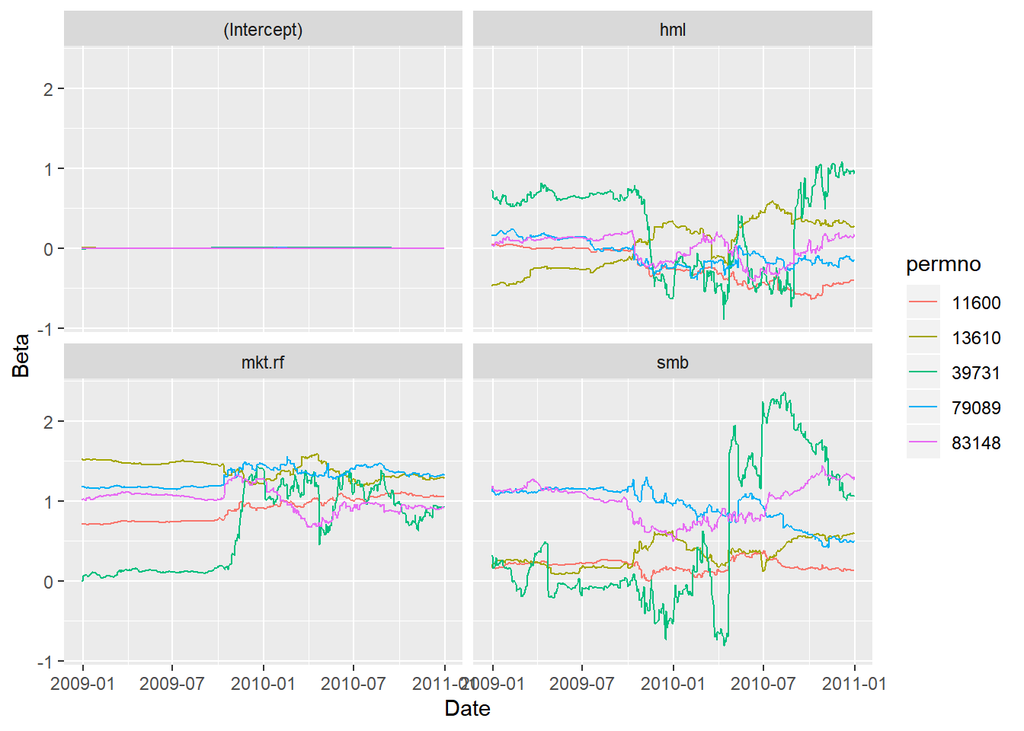

```r
library(ggplot2)
# ammend the permno to factor type for plotting purpose
reg.ff$permno = as.factor(reg.ff$permno)

p = reg.ff %>% ggplot(aes(x=date,y=estimate,color=permno)) +
  geom_line() +
  labs(x = 'Date',
       y = 'Beta') +
  facet_wrap(facets = ~term)
print(p)
```

## Step 6. Calculate the monthly correlation of beta for each stock

```r
library(zoo)
reg.ff.m = reg.ff %>% mutate(yymm = as.yearmon(date)) %>%
  group_by(permno,yymm,term) %>%
  summarise(beta = mean(estimate,na.rm=T)) %>% ungroup()

head(reg.ff.m)
```

```
## # A tibble: 6 x 4
##   permno yymm      term             beta
##   <fct>  <yearmon> <chr>           <dbl>
## 1 11600  Dec 2008  (Intercept) -0.000486
## 2 11600  Dec 2008  hml          0.0424
## 3 11600  Dec 2008  mkt.rf       0.713
## 4 11600  Dec 2008  smb          0.176
## 5 11600  Jan 2009  (Intercept) -0.000614
## 6 11600  Jan 2009  hml          0.0389
```

```r
reg.beta.cor = reg.ff.m %>%
  group_by(permno,term) %>%
  arrange(yymm) %>%
  mutate(beta.lag = lag(beta,1)) %>%
  na.omit() %>%
  summarise(cor = cor(beta,beta.lag)) %>% ungroup()
reg.beta.cor
```

```
## # A tibble: 20 x 3
##    permno term          cor
##    <fct>  <chr>       <dbl>
##  1 11600  (Intercept) 0.902
##  2 11600  hml         0.959
##  3 11600  mkt.rf      0.970
##  4 11600  smb         0.629
##  5 13610  (Intercept) 0.869
##  6 13610  hml         0.937
##  7 13610  mkt.rf      0.815
##  8 13610  smb         0.858
##  9 39731  (Intercept) 0.947
## 10 39731  hml         0.765
## 11 39731  mkt.rf      0.891
## 12 39731  smb         0.903
## 13 79089  (Intercept) 0.917
## 14 79089  hml         0.908
## 15 79089  mkt.rf      0.903
## 16 79089  smb         0.946
## 17 83148  (Intercept) 0.866
## 18 83148  hml         0.766
## 19 83148  mkt.rf      0.819
## 20 83148  smb         0.917
```

```r
reg.beta.cor = spread(reg.beta.cor,permno,cor)
reg.beta.cor
```

```
## # A tibble: 4 x 6
##   term        `11600` `13610` `39731` `79089` `83148`
##   <chr>         <dbl>   <dbl>   <dbl>   <dbl>   <dbl>
## 1 (Intercept)   0.902   0.869   0.947   0.917   0.866
## 2 hml           0.959   0.937   0.765   0.908   0.766
## 3 mkt.rf        0.970   0.815   0.891   0.903   0.819
## 4 smb           0.629   0.858   0.903   0.946   0.917
```